# Imperfect Data

Session 9

2026-11-03

## The study you run is not the study you planned

- Your PAP describes the study you planned.
- The study that runs departs from it:
  - some participants won’t use the tool
  - some API calls time out
  - some judge outputs fail to parse.
- Each departure changes what the data can tell you.
- Your job after registration:
  - measure every departure
  - analyze the study you actually ran
  - report the gap against the plan.

Analyses you planned are confirmatory.

Analyses you chose after seeing the data are exploratory.

## Planned design, realized design

- The PAP declares a design: **M**odel, **I**nquiry, **D**ata strategy, **A**nswer strategy.
- Each part of the data strategy is carried out imperfectly:
  - **Sampling:** who or what actually enters the study.
  - **Assignment:** who actually receives each treatment.
  - **Measurement:** which outcomes are actually recorded.

Planned

- 200 participants, 100 offered the tutor.
- Everyone offered the tutor uses it.
- Every quiz is scored.

Realized

- 194 start; 61 of the 97 offered open the tutor.
- 23 leave before the quiz, 17 of them in the tutor arm.
- 4 free-text answers fail to parse.
- End the study with a *realized design* to compare with the *planned design*.
  - Diagnose it like the plan.

[Blair, Coppock & Humphreys (2023), *Research Design in the Social Sciences*, Princeton University Press, ch. 22.](https://book.declaredesign.org/lifecycle/realization.html)

## How AI evaluations go wrong

Treatment received differs

- Participants offered the tool never open it.
- Control participants use ChatGPT anyway.
- The agent skips the retrieval tool call.
- A router falls back to another model.
- $\implies$ **noncompliance**

Outcome goes missing

- Participants leave before the outcome.
- Calls time out or hit rate limits.
- The model refuses.
- The judge’s output fails to parse.
- $\implies$ **attrition**

The instrument changes

- A model alias points to a new snapshot mid-study.
- The provider retires your pinned snapshot.
- $\implies$ treatment changes for everyone at once
- GPT-4, March to June 2023. Prime identification fell from **84%** to **51%**. Directly executable code fell from **52%** to **10%**, mostly from added markdown fences.

[Chen, Zaharia & Zou (2024), *How Is ChatGPT’s Behavior Changing over Time?*, Harvard Data Science Review 6(2).](https://doi.org/10.1162/99608f92.5317da47)

# Noncompliance

## Assigned treatment versus received treatment

- **Running example:** 200 participants study for a 0–100 quiz. A random 100 are offered an AI tutor.
- $Z_i=1$ if participant $i$ is **assigned** the tutor.
- $D_i(z)$: whether $i$ **receives** it under assignment $z$. Observed: $D_i=D_i(Z_i)$, here “opened the tutor at least once”.
- $Y_i(z)$: $i$’s quiz score under assignment $z$.
- Randomization controls $Z_i$. Participants choose $D_i$.
- Model-only studies have the same gap. The retrieval Bundle’s agent decides whether to call the retrieval tool.
  - $D_i=1$ only if retrieval actually ran on question $i$.
- Motivated participants open the tutor ($D_i=1$) and would score higher without it.
- Comparing takers ($D_i=1$) to non-takers ($D_i=0$) compares different kinds of people.

## Take-up in AI-tool field experiments

- **Cui et al.:** GitHub Copilot access randomized among developers at Microsoft, Accenture, and a Fortune 100 firm.
- **Microsoft, 1,746 developers:**
  - **8.5%** of the treated group signed up in the first two weeks.
  - Two reminder emails raised take-up to **42.5%**.
- Across the three firms, 30–40% of treated engineers never tried the tool.

[figure not shown]

- Gerber & Green: *“The subjects who are actually treated are a non-random subset of the original treatment group. This point cannot be emphasized enough.”*
- The developers who adopted early are the ones most eager for the tool.

[Cui, Demirer, Jaffe, Musolff, Peng & Salz (2025), *The Effects of Generative AI on High-Skilled Work: Evidence from Three Field Experiments with Software Developers*, Management Science.](https://doi.org/10.1287/mnsc.2025.00535)

[Gerber & Green (2012), *Field Experiments: Design, Analysis, and Interpretation*, Norton, ch. 5, p. 134.](https://wwnorton.com/books/9780393979954)

## The intent-to-treat effect survives

- The **intent-to-treat** (ITT) effect is the effect of being assigned:

$$\mathrm{ITT}=\frac{1}{N}\sum_{i}\big[Y_i(1)-Y_i(0)\big],\qquad \widehat{\mathrm{ITT}}=\bar Y_{Z=1}-\bar Y_{Z=0}.$$

- Random assignment makes $\widehat{\mathrm{ITT}}$ unbiased, whatever participants do afterwards.
  - Its standard error is lecture 06’s difference-in-means SE.
- Take-up has its own ITT: $\mathrm{ITT}_D=\frac{1}{N}\sum_i\big[D_i(1)-D_i(0)\big]$.
  - Estimated by $\widehat{\mathrm{ITT}}_D=\bar D_{Z=1}-\bar D_{Z=0}$.
- The ITT answers a deployment question: what happens when you **offer** the tool?
  - Deployment also offers. Users decide whether to use it.
- Report it first, as the primary analysis.

## One-sided noncompliance and the complier effect

- **One-sided:** only the treatment arm can deviate. $D_i(0)=0$ for everyone.
- **Compliers** take the tutor when offered: $D_i(1)=1$. **Never-takers** do not: $D_i(1)=0$.
- Assignment cannot change a never-taker’s score, so the ITT is the compliers’ effect, diluted:

$$\mathrm{ITT}=\mathrm{ITT}_D\cdot\mathrm{CACE}+(1-\mathrm{ITT}_D)\cdot 0.$$

- So the **complier average causal effect** is the ITT scaled up by take-up:

$$\mathrm{CACE}=\operatorname{E}\big[Y_i(1)-Y_i(0)\mid D_i(1)=1\big]=\frac{\mathrm{ITT}}{\mathrm{ITT}_D}.$$

[Gerber & Green (2012), *Field Experiments: Design, Analysis, and Interpretation*, Norton, ch. 5, Theorem 5.1.](https://wwnorton.com/books/9780393979954)

## Estimating the complier effect

$$\widehat{\mathrm{CACE}}=\frac{\bar Y_{Z=1}-\bar Y_{Z=0}}{\bar D_{Z=1}-\bar D_{Z=0}},\qquad \widehat{\mathrm{SE}}\big(\widehat{\mathrm{CACE}}\big)\approx\frac{\widehat{\mathrm{SE}}\big(\widehat{\mathrm{ITT}}\big)}{\widehat{\mathrm{ITT}}_D}.$$

- This is instrumental variables with $Z$ as the instrument. Two-stage least squares gives the same estimate: `iv_robust(Y ~ D | Z, data)`.
- **Gerber & Green, New Haven 1998:** 1,445 people assigned a get-out-the-vote canvass, 5,645 controls.
  - Turnout 41.4% against 37.5%: $\widehat{\mathrm{ITT}}=3.8$ points.
  - Canvassers reached 395 of the 1,445: $\widehat{\mathrm{ITT}}_D=0.27$.
  - $\widehat{\mathrm{CACE}}=3.84/0.273=14.1$ points, 95% CI 3.8 to 24.3.
- **Cui et al.:** Copilot adoption raised completed pull requests by **26%** (SE 10%).

[Gerber & Green (2012), *Field Experiments*, ch. 5, Table 5.2.](https://wwnorton.com/books/9780393979954)

[Cui et al. (2025), Management Science.](https://doi.org/10.1287/mnsc.2025.00535)

## Simulation: four ways to analyze one study

- **Simulation:** 60% of participants would open the tutor if offered. The tutor adds 6 points for them. Motivated participants open it more and score higher anyway.

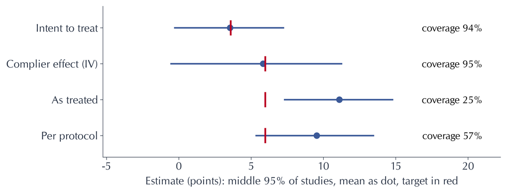

- **As treated** compares everyone who opened the tutor with everyone who did not. **Per protocol** drops treated participants who never opened it.
- Both compare motivated takers with a less motivated group. Both overstate the 6-point effect.
  - In New Haven, the canvassed against controls gives 16.9 points, against the CACE of 14.1.

## What the complier effect assumes

- The ITT needs random assignment and non-interference. The CACE adds two assumptions.
- **Excludability:** assignment matters only through receipt, $Y_i(z,d)=Y_i(d)$.
  - Fails if participants told they *have* a tutor study less, whether or not they open it.
  - Fails if the retrieval Bundle’s system prompt mentions course materials even when retrieval never runs.
- A direct effect $\delta$ on never-takers biases the ratio by $\delta\,(1-\mathrm{ITT}_D)/\mathrm{ITT}_D$. At 20% take-up that is $4\delta$.
- **Non-interference:** $i$’s outcome depends only on $i$’s own assignment.
  - Fails if participants share tutor answers in a course group chat.
  - Fails if both arms share one rate limit, so treatment calls slow down control calls.
- **One-sidedness:** the control arm has no access. Control participants using another chatbot make it two-sided.

## Two-sided noncompliance

| Type | $D_i(0)$ | $D_i(1)$ |
| --- | --- | --- |
| Never-taker | 0 | 0 |
| Complier | 0 | 1 |
| Always-taker | 1 | 1 |
| Defier | 1 | 0 |

- **Always-takers** use an AI tool whatever they are assigned, like controls who use ChatGPT anyway.
- **Defiers** use one only when told not to.
- **Monotonicity:** $D_i(1)\ge D_i(0)$ for every $i$. There are no defiers.
- Under monotonicity and excludability the same ratio identifies the CACE:

$$\mathrm{CACE}=\frac{\mathrm{ITT}}{\mathrm{ITT}_D},\qquad \mathrm{ITT}_D=\Pr(\text{complier}).$$

- **Gerber & Green, NYC mayoral debate:** viewing encouraged at random. 20.5% compliers, 16.2% always-takers, 63.4% never-takers. $\widehat{\mathrm{CACE}}=0.057/0.205=0.28$.

[Gerber & Green (2012), *Field Experiments*, ch. 6, Tables 6.2–6.3.](https://wwnorton.com/books/9780393979954)

## Who are the compliers?

- The CACE is the effect for compliers only. Nobody is labeled a complier in the data.
  - A treated taker might be a complier or an always-taker.
- Their **share** is identified: $\widehat{\mathrm{ITT}}_D$.
- Under one-sided noncompliance, the treated takers *are* the compliers. Their pretreatment covariates are visible.
- **Simulation, one study:** 52% of those offered open the tutor. Their mean prior grade is +0.45 SD, against +0.07 for everyone.
- The CACE describes motivated, higher-achieving students.
- Ask which population your decision concerns.
  - A tool everyone will be required to use: the CACE speaks only for compliers.
  - A tool users can choose: the ITT at deployment’s take-up rate.

## Low take-up costs power

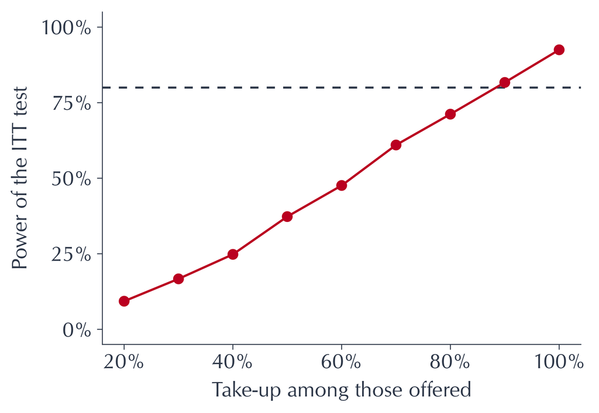

- $N=200$, 6 points for compliers.
- $\mathrm{ITT}=\mathrm{ITT}_D\cdot\mathrm{CACE}$, so the sample needed grows as $1/\mathrm{ITT}_D^{2}$.
  - Planned take-up 90%, realized 40%: about $(0.9/0.4)^2\approx5$ times the sample.
- **Gerber & Green:** take-up falling from 100% to 10% needs 100 times the sample.
- Raising take-up is usually cheaper than recruiting. Default the tool on, onboard participants, send reminders.
  - **Cui et al.:** two reminder emails took Copilot take-up from 8.5% to 42.5%.

[Gerber & Green (2012), *Field Experiments*, ch. 5, p. 161.](https://wwnorton.com/books/9780393979954)

## Summary: noncompliance

- Analyze as assigned first: $\widehat{\mathrm{ITT}}=\bar Y_{Z=1}-\bar Y_{Z=0}$ is unbiased whatever participants do.
- $\widehat{\mathrm{CACE}}=\widehat{\mathrm{ITT}}/\widehat{\mathrm{ITT}}_D$ is the effect for compliers. It assumes excludability, non-interference, and monotonicity.
- As-treated and per-protocol comparisons select on a post-assignment choice. In the simulation they overstate the effect.
- Report the take-up rate and the compliers’ covariate profile next to the CACE.
- Power falls with take-up squared. Design for take-up.

# Attrition

## Missing outcomes break the comparison

- $R_i(z)=1$ if unit $i$’s outcome is **recorded** under assignment $z$.
- Dropping missing rows gives the **complete-case** estimator:

$$\hat\Delta_{\text{cc}}=\bar Y_{Z=1,R=1}-\bar Y_{Z=0,R=1}.$$

- Randomization balanced the arms *before* anyone went missing.
- When missingness differs by arm, the units that remain can differ in ways that also drive the outcome.
- **RAND Health Insurance Experiment:** families randomized to plans ranging from free care to paying most costs themselves.
  - 8% refused to enroll in the free plan, 25% in the plan with the most cost sharing. Their outcomes are missing.
  - Families expecting large medical bills had the most reason to refuse cost sharing. The cost-sharing arms that remain look healthier.

[Gerber & Green (2012), *Field Experiments*, ch. 7, pp. 212–214.](https://wwnorton.com/books/9780393979954)

[Aron-Dine, Einav & Finkelstein (2013), *The RAND Health Insurance Experiment, Three Decades Later*, Journal of Economic Perspectives 27(1).](https://doi.org/10.1257/jep.27.1.197)

## Running example: refusals in a labelling task

- **Model-only study:** an LLM labels 1,000 posts as hateful or not. Expert gold labels exist for all of them.
- A random 500 get a codebook prompt that asks the model to quote the hateful phrase. The rest get a one-line instruction.
- $Y_i=100$ if the model’s label matches gold, 0 if not.
- The model refuses 3% of posts at random under either prompt.
- Under the codebook it also refuses to quote the most explicit posts.
- Explicit posts are the easiest to label. $\hat\Delta_{\text{cc}}$ compares harder codebook posts with all the others.
- Prompts move refusal rates a lot. **Röttger et al.:** Llama-2-70b-chat refused **38%** of 250 safe prompts with its default system prompt, **14%** without.

[Röttger et al. (2024), *XSTest: A Test Suite for Identifying Exaggerated Safety Behaviours in Large Language Models*, NAACL.](https://doi.org/10.18653/v1/2024.naacl-long.301)

## When missingness is harmless

- **Missing independent of potential outcomes** (MIPO):

$$Y_i(z)\perp R_i(z).$$

- Under MIPO, the recorded units in each arm are a random subsample. $\hat\Delta_{\text{cc}}$ is unbiased.
- **MIPO given covariates:** $Y_i(z)\perp R_i(z)\mid X_i$. Reweight each recorded unit by its arm’s response rate $\hat q_z(X_i)$ at its covariate value:

$$\hat\mu_z=\frac{\sum_{i:Z_i=z}R_iY_i/\hat q_z(X_i)}{\sum_{i:Z_i=z}R_i/\hat q_z(X_i)}.$$

- Both are claims about outcomes you did not see. Neither can be tested.
- In the refusal example, MIPO fails: refusals ($R_i=0$) concentrate on explicit posts, which have high $Y_i$.

[Gerber & Green (2012), *Field Experiments*, ch. 7.](https://wwnorton.com/books/9780393979954)

## Diagnosing attrition

- Equal attrition rates are weak reassurance. Run two checks:
  1. **Attrition by arm:** regress $R_i$ on $Z_i$. A difference means treatment changes who is missing.
  2. **Who is missing:** regress $R_i$ on $Z_i$, $X_i$, and $Z_iX_i$. An interaction means treatment changes *which* units go missing.
     - $X_i$: a toxicity score from an off-the-shelf classifier, computed before assignment.

One simulated study

| Arm | Posts | Refused | Toxicity, labelled | Toxicity, refused |
| --- | --- | --- | --- | --- |
| Codebook | 500 | 82 | -0.21 | 0.72 |
| One-line instruction | 500 | 10 | 0.04 | 0.01 |

- The codebook’s labelled share is 14 points lower, $p<0.001$. Interaction with toxicity: $p<0.001$.

## Bounding the effect

- **Extreme-value bounds:** fill every missing outcome with the scale’s minimum or maximum. With $q_z$ the share recorded in arm $z$:

$$\Delta^{\pm}=\big[q_1\bar Y_{1}^{R=1}+(1-q_1)\,y^{\pm}\big]-\big[q_0\bar Y_{0}^{R=1}+(1-q_0)\,y^{\mp}\big].$$

- Here $y^{+}=100$ (correct) and $y^{-}=0$ (wrong). The width is $(2-q_0-q_1)\times100$ points, whatever the data say.
- **Trimming bounds (Lee):** assume **monotonicity**: the codebook can only cause a refusal, $R_i(1)\le R_i(0)$.
  - The arm with fewer refusals holds extra units. Trim the share $p=(q_0-q_1)/q_0$ from its top or its bottom:

$$\Delta^{\text{lower}}=\bar Y_{1}^{R=1}-\bar Y_{0}^{R=1,\,\text{top }1-p},\qquad \Delta^{\text{upper}}=\bar Y_{1}^{R=1}-\bar Y_{0}^{R=1,\,\text{bottom }1-p}.$$

- These bound the effect on **always-labelled** posts, labelled under either prompt.

[Lee (2009), *Training, Wages, and Sample Selection: Estimating Sharp Bounds on Treatment Effects*, Review of Economic Studies 76(3).](https://doi.org/10.1111/j.1467-937X.2009.00536.x)

## Simulation: estimates under differential refusals

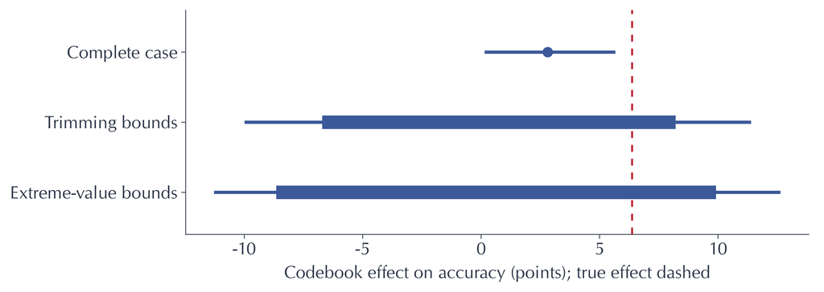

- Studies of 5,000 posts. The codebook raises accuracy by 6.4 points. It is refused on 16% of posts, against 3% without it.
- Thin bars span the middle 95% of studies. **Complete case:** 2.8 on average. Its interval covers 28% of the time.
- Thick bars are the **bounds** averaged over studies: trimming [-6.7, 8.2], extreme-value [-8.7, 9.9].
  - With a 0/1 outcome, trimming removes only correct labels or only wrong ones. It buys little.

## Bounds on real data

- **Gerber & Green, Colombian school vouchers (PACES):** 3,542 lottery applicants, 2,073 winners.
  - Test scores exist only for students who registered for the national exam.
  - 37.6% of winners registered, against 30.2% of losers.
- Complete case: 47.6 against 46.9, a difference of **0.7** points.
- **Extreme-value bounds** on the 0–100 scale: **[−66.1, 66.1]**.
- **Trimming bounds:** trim 19.6% of the winners’ scores. **[−0.8, 2.7]**.
- A continuous score lets trimming work. Accuracy on a 0/1 scale does not.
- Bounds are estimates too. Their endpoints have sampling error.
  - An interval for the bounds widens them further (Imbens & Manski 2004).

[Gerber & Green (2012), *Field Experiments*, ch. 7, pp. 230–236.](https://wwnorton.com/books/9780393979954)

[Imbens & Manski (2004), *Confidence Intervals for Partially Identified Parameters*, Econometrica 72(6).](https://doi.org/10.1111/j.1468-0262.2004.00555.x)

## Spending effort on the missing

- **Double sampling:** after the main collection, draw a **random** subsample of the units with missing outcomes. Spend heavily to measure them.
- The subsample stands in for all missing units in its arm:

$$\hat\mu_z=q_z\,\bar Y_z^{R=1}+(1-q_z)\,\bar Y_z^{\text{follow-up}}.$$

- If some follow-ups also fail, bound only those.
- **Gerber & Green simulation:** true effect 0.10, complete case 0.001, with a random follow-up 0.085.
- In an AI evaluation, follow-up is often cheap. For a random sample:
  - rerun timed-out calls with a longer timeout
  - hand-score unparseable judge outputs
  - pay dropouts a bonus to finish the outcome survey.
- The sample must be random. Chasing the easiest cases first breaks it.

[Gerber & Green (2012), *Field Experiments*, ch. 7.6, Table 7.6.](https://wwnorton.com/books/9780393979954)

## Refusals: missing data or an outcome?

- A moderation system classifies every post with the codebook prompt. The model refuses some posts, mostly the most explicit ones.

Measuring the classifier: missing data

- How accurate are the model’s classifications?
- A refusal produces no classification. The post stays unlabelled.
- Treat it as missing. Bound the codebook’s effect on accuracy.

Measuring the system: an outcome

- How accurate are the system’s decisions?
- A refusal still ends in a decision, explicit or by default. Here the post stays up.
- Score that decision. A hateful post left up is an error.
- What a refusal means depends on the system around the model and the question you ask of it.
- Simply dropping missing values will not likely be the ideal solution.

## Summary: attrition

- Dropping missing rows is unbiased only under MIPO, $Y_i(z)\perp R_i(z)$. MIPO cannot be tested.
- Diagnose attrition by arm, and by pretreatment covariates within arm.
- Bounds drop the assumption. Extreme-value bounds are always valid and often wide. Trimming bounds assume monotonicity, and won’t help much with 0/1 outcomes.
- A random follow-up sample of the missing may help.
- What a refusal means depends on the system and the question.

# Pivoting

## Continue or change the design

- Re-diagnose the design at your pilot’s take-up, refusal, and attrition rates, and at its outcome distributions.
- **Continue** when the realized design still answers the question.
- **Change** the design when it does not.
- Example: the primary outcome barely varies.
  - The model answers 98% of items correctly under both prompts. It has almost no room to move.
- The primary hypothesis may move to an outcome that varies. Every registered outcome is still reported.

| Original plan | Deviation | Reason |
| --- | --- | --- |
| Primary: accuracy on all items | Primary: accuracy on hard items | Ceiling effects |

[Blair, Coppock & Humphreys (2023), *Research Design in the Social Sciences*, ch. 22.1.](https://book.declaredesign.org/lifecycle/realization.html)

## Reporting the realized design

- Lecture 07’s reconciliation tables list each departure from the plan. Report the realized design next to them:
  - **Data strategy:** take-up, attrition, and refusals by arm. Every model id the provider reported.
  - **Inquiry:** the estimand behind each number. ITT or CACE; accuracy on labelled posts or the pipeline’s decisions.
  - **Answer strategy:** the registered estimate first. Then the CACE and the bounds, labeled as such.
- Re-diagnose at the realized rates: power, bias, and coverage.
- A reader can then judge how much to trust the answer.

[Blair, Coppock & Humphreys (2023), *Research Design in the Social Sciences*, ch. 22.4.](https://book.declaredesign.org/lifecycle/realization.html)

# Before session 10

## For next week

- Session 10 is a workshop. Bring some initial data.

What is arriving

- take-up, refusals, and attrition by arm
- the outcome’s distribution in each arm
- API errors, timeouts, and unparseable judge output
- the model ids the API reports

How it differs from the plan

- rates against those in your diagnosis
- outcomes stuck at a ceiling or floor
- failures your pipeline does not handle yet
- units that look different from the ones you expected
- Re-diagnose plugging in what you now know about your data. Come with a first call: continue, or change the design and record the deviation.

## Next week’s readings

- **Blair, Coppock & Humphreys (2023), ch. 22 “Realization”:** every team. Pivoting, the populated PAP, reconciliation, and writing up the design you ran.
- **Gerber & Green (2012), as useful for your study:**
  - **ch. 5, one-sided noncompliance:** treated units can decline the treatment. Participants never open the tool; the agent skips the tool call.
  - **ch. 6, two-sided noncompliance:** control units can get it too. Control participants use ChatGPT; a router sends control calls to the treatment model.
  - **ch. 7, attrition:** outcomes go missing. Dropouts, refusals in a labelling task, timeouts, unparseable judge output.
- Reflection memos on these readings: **post by 9 November**, 24 hours before session 10.

[Blair, Coppock & Humphreys (2023), *Research Design in the Social Sciences*, Princeton University Press, ch. 22.](https://book.declaredesign.org/lifecycle/realization.html)

[Gerber & Green (2012), *Field Experiments: Design, Analysis, and Interpretation*, Norton, chs. 5–7.](https://wwnorton.com/books/9780393979954)